# Fun with R: Ecological data analysis in R

## The `lattice` package

The `lattice` package is an implementation of the **Trellis** display (or multi-panel display) used to visualize multivariate data or, more specifically, to visualize the dependencies and interactions between multiple variables.

### Univariate distribution

Let’s look at a simple example where the density distribution of Petal.Length is conditioned by Species.

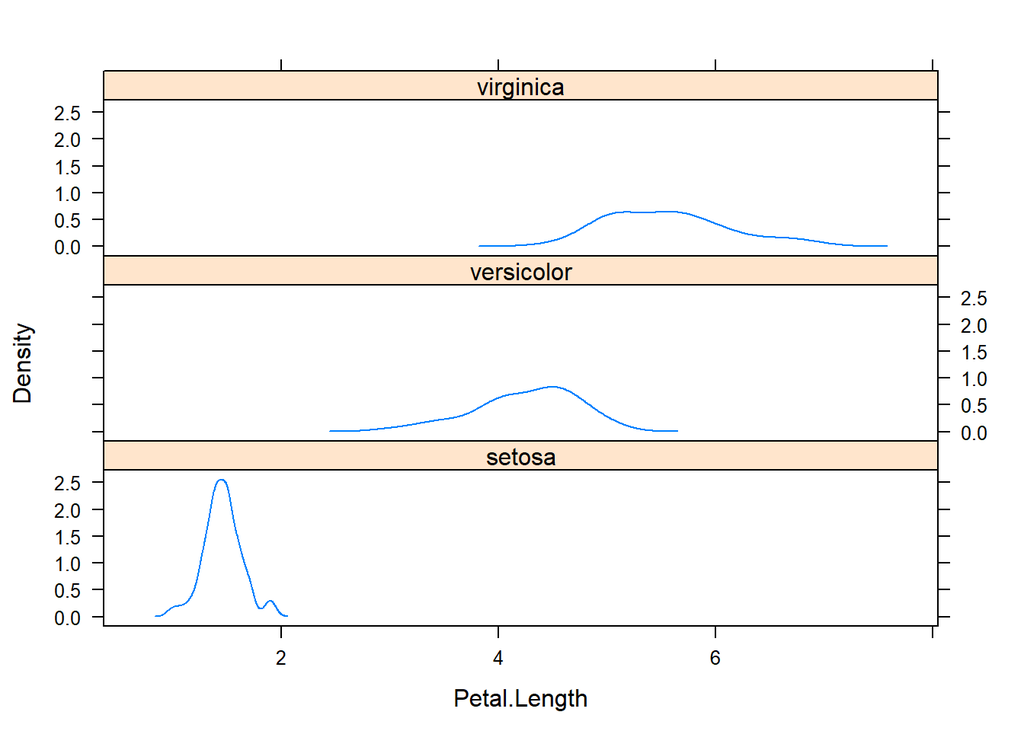

```r
library(lattice)
densityplot(~ Petal.Length| Species, iris, plot.points = "", layout=c(1,3))
```

The `layout=c(1,3)` parameter instructs the lattice function to layout the panels along 1 column and 3 row. If you wanted the plots to be displayed in 1 rows and 3 column you would simply type `layout=c(3,1)` which is teh default option.

The `lattice` packages also has a histogram function

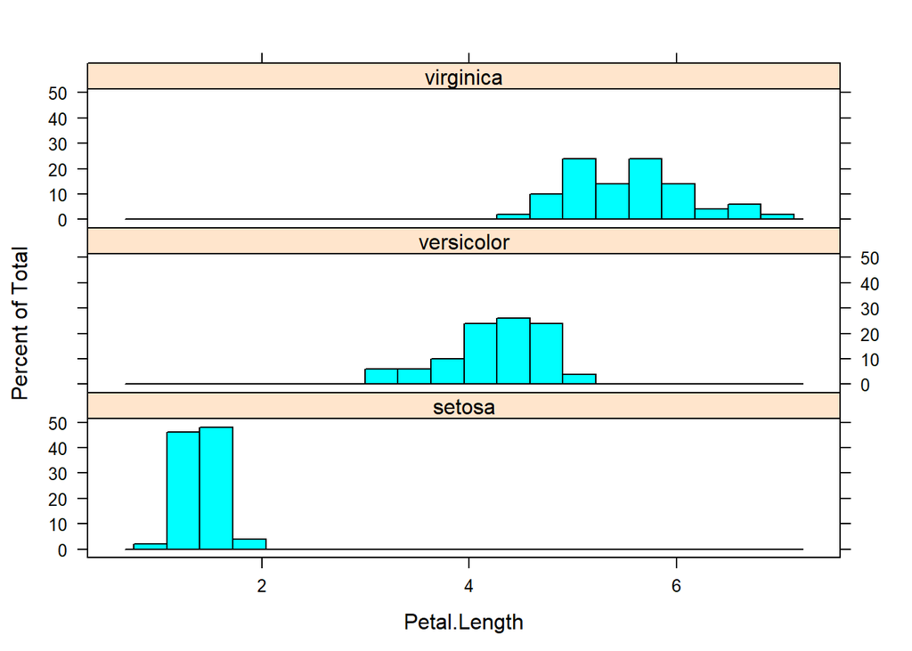

```r
histogram(~ Petal.Length| Species, iris, plot.points = "", nint = 20, layout=c(1,3))
```

Note the importance of having a table shaped in “long form”. The density plots are conditioned on **species** which requires that crop type be treated as different values of a same variable (i.e. column `Species` in `iris`). The above plot could not be generated if the **species** crop were treated as separate variable variables (i.e. columns)in iris.

You can also compare the distributions to a normal distribution (i.e. a Q-Q plot):

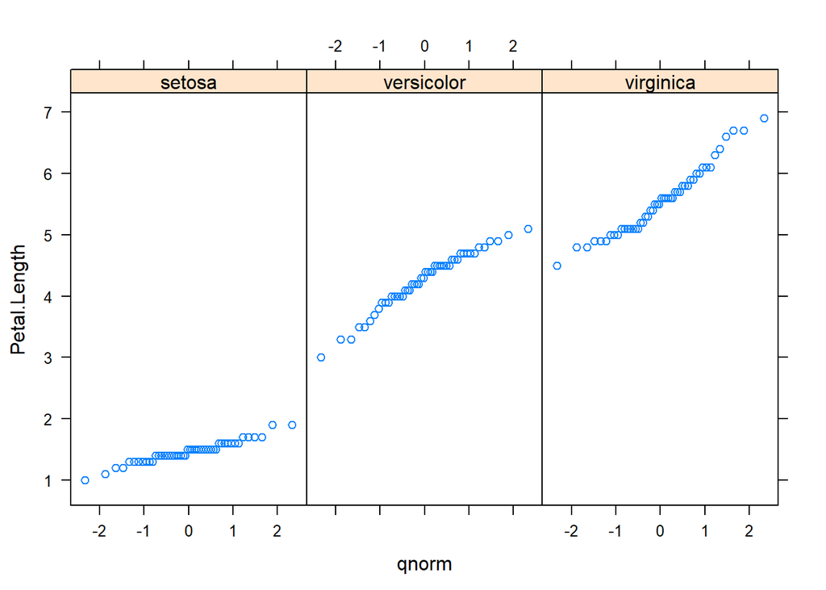

```r
qqmath(~ Petal.Length| Species, iris, plot.points = "", nint = 20, layout=c(3,1))
```

Boxplots are another popular way to view the distribution of values. In the following example, we create boxplots of Petal Length as a function of a dummy variable `variety` (`Petal.Length ~ variety`) and condition this comparison on species (`|Species`)

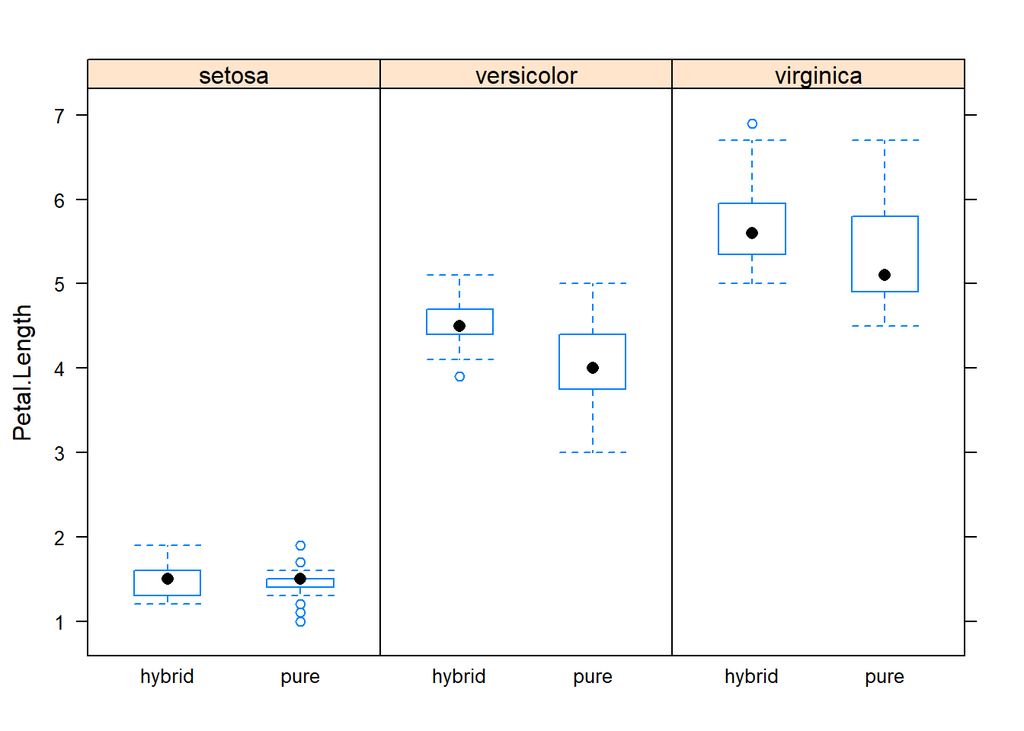

```r
iris$variety<-rep(c(rep('pure',25), rep('hybrid',25)),3) # dummy variable
bwplot(Petal.Length ~  variety|Species, iris)
```

### Multivariate data

#### Scatter plots

The Lattice package allows us to plot several variables on a same plot. For example, we can plot `Sepal.Length + Sepal.Width` vs `Petal.Length + Petal.Width` for each `Species` on a same plot:

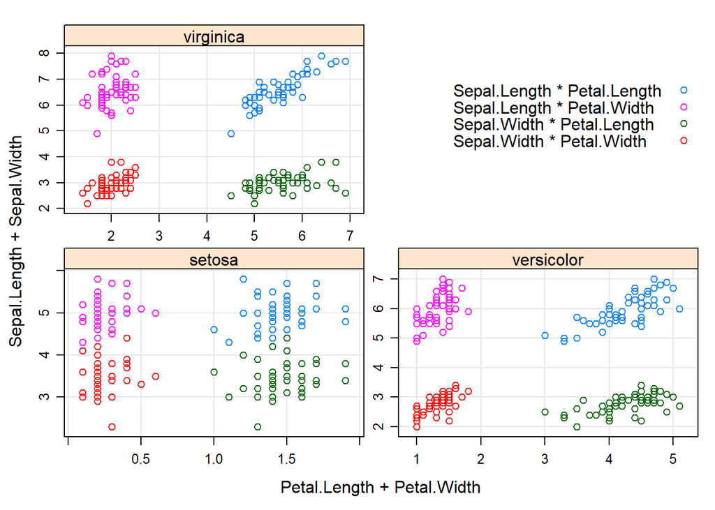

```r
xyplot(Sepal.Length + Sepal.Width ~ Petal.Length + Petal.Width | Species,
       data = iris, scales = "free", layout = c(2, 2), type=c("p","g"),
       auto.key = list(x = .6, y = .7, corner = c(0, 0)))
```

The `xyplot` function is passed several parameters. The parameter type = c(“p”,“g”) instructs the function to generate both points, “p”, and a background grid ,“g”. Parameter `type` can accept many other options, a few are listed in the following table:

| Option | Adds |
| --- | --- |
| `"p"` | `Points` |
| `"l"` | `Lines` |
| `"b"` | `Both points and lines` |
| `"o"` | `Both points and lines` |
| `"r"` | `Regression line` |
| `"g"` | `Reference grid` |
| `"smooth"` | `LOESS fit` |
| `"spline"` | `Cubic spline fit` |

Let’s check how `Petal.Length` is related to other variables in each species

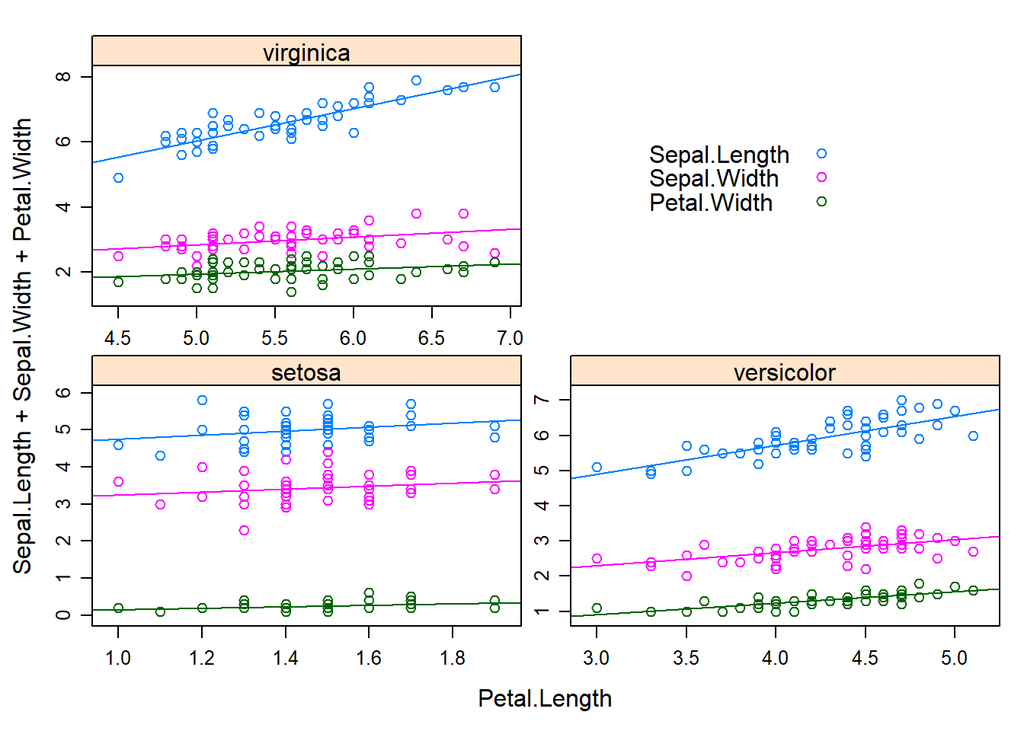

```r
xyplot(Sepal.Length + Sepal.Width + Petal.Width ~ Petal.Length  | Species,
       data = iris, scales = "free", layout = c(2, 2), type=c("p","r"),
       auto.key = list(x = .6, y = .7, corner = c(0, 0)))
```

#### Basic line plots

After `order` my data `iris` by `Petal.Length`

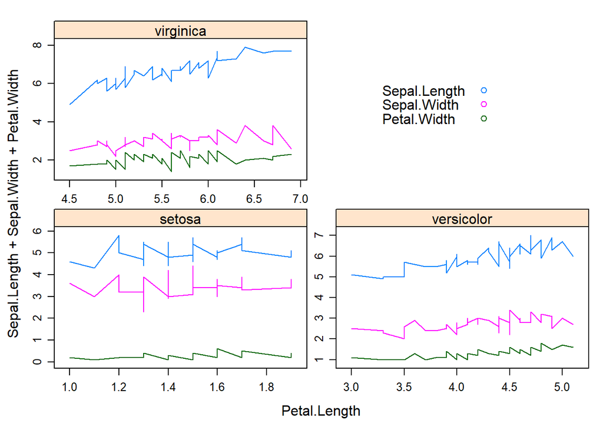

```r
xyplot(Sepal.Length + Sepal.Width + Petal.Width ~ Petal.Length  | Species,
       data = iris[order(iris$Petal.Length),], scales = "free", layout = c(2, 2), type=c("l"), auto.key = list(x = .6, y = .7, corner = c(0, 0)))
```

We can take this a step further. We could condition the previous relationship by species and variety.

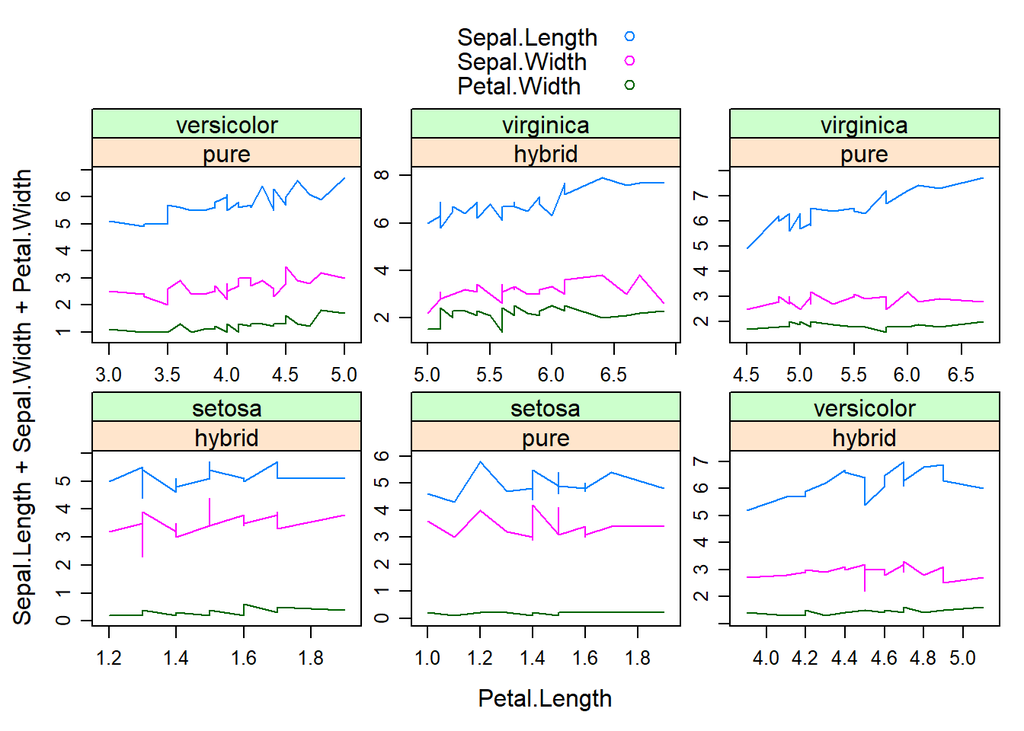

```r
xyplot(Sepal.Length + Sepal.Width + Petal.Width ~ Petal.Length  | variety+Species,
       data = iris[order(iris$Petal.Length),], scales = "free", layout = c(3, 2), type=c("l"),
       auto.key = T)
```

### Customizing trellis plots

As the `par` function mentioned ealier, Various elements of a trellis plot can be customized by passing the graphic parameters to the `trellis.par.set` function. To get the list of graphic parameters and their values call:

```r
trellis.par.get()
```

It gives you an idea about how many parameters can be customized. Those defaults can be store in an object to further restore them. Many tutorials are available online on the `lattice` package in order to customize your plotas you need.

## The `ggplot` package

*Tutorial from Manny Gimond (2020)*

The `ggplot2` package is designed around the idea that statistical graphics can be decomposed into a formal system of grammatical rules. The `ggplot2` learning curve is the steepest of all graphing environments encountered thus far, but once mastered it affords the greatest control over graphical design. For an up-to-date list of `ggplot2` functions, you may want to refer to ggplot2’s [website](https://ggplot2.tidyverse.org/reference/).

A plot in `ggplot2` consists of different *layering components*, with the three primary components being:

- The **dataset** that houses the data to be plotted;
- The **aesthetics** which describe how data are to be mapped to the geometric elements (color, shape, size, etc..);
- The **geometric elements** to use in the plot (i.e. points, lines, rectangles, etc…).

Additional (optional) layering components include:

- **Statistical** elements such as smoothing, binning or transforming the variable
- **Facets** for conditional or trellis plots
- **Coordinate systems** for defining the plots shape (i.e. cartesian, polar, spatial map projections, etc…)

To access `ggplot2` functions, you will need to load its library:

```r
library(ggplot2)
```

Today, we will use the following datasets:

1. `dat1`: grain harvest for north america + several long and wide versions of this dataset. Examine the following objects created.

```r
library(tidyr)
library(dplyr)

dat1 <- read.csv("Data/FAO_grains_NA.csv", header=TRUE)

dat1w <- dat1 %>%
         filter(Information == "Yield (Hg/Ha)",
                Country =="United States of America",
                Crop %in% c("Oats", "Maize", "Barley", "Buckwheat","Rye")) %>%
                select (Year, Crop, Value) %>% spread(key = Crop, value="Value")

dat1l <- gather(dat1w, key = "Crop", value = "Yield", 2:6)

dat1l2 <- dat1 %>%
          filter(Information == "Yield (Hg/Ha)",
                 Crop       %in% c("Oats", "Maize", "Barley", "Buckwheat","Rye")) %>%
          select( Year, Crop, Country,  Yield = Value)  # Note that we are renaming the Value field
```

2. `dat2`: ncome/education census data for the US

```r
dat2 <- read.csv("Data/Income_education.csv", header=TRUE)
```

From a grammatical perspective, a scientific graph is the conversion of *data* to **aesthetic** attributes and **geometric** objects. This is an important concept to grasp since it underlies the construction of all graphics in `ggplot2`.

For example, if we want to generate a point plot of crop yield as a function of year using the `dat1l` data frame, we type:

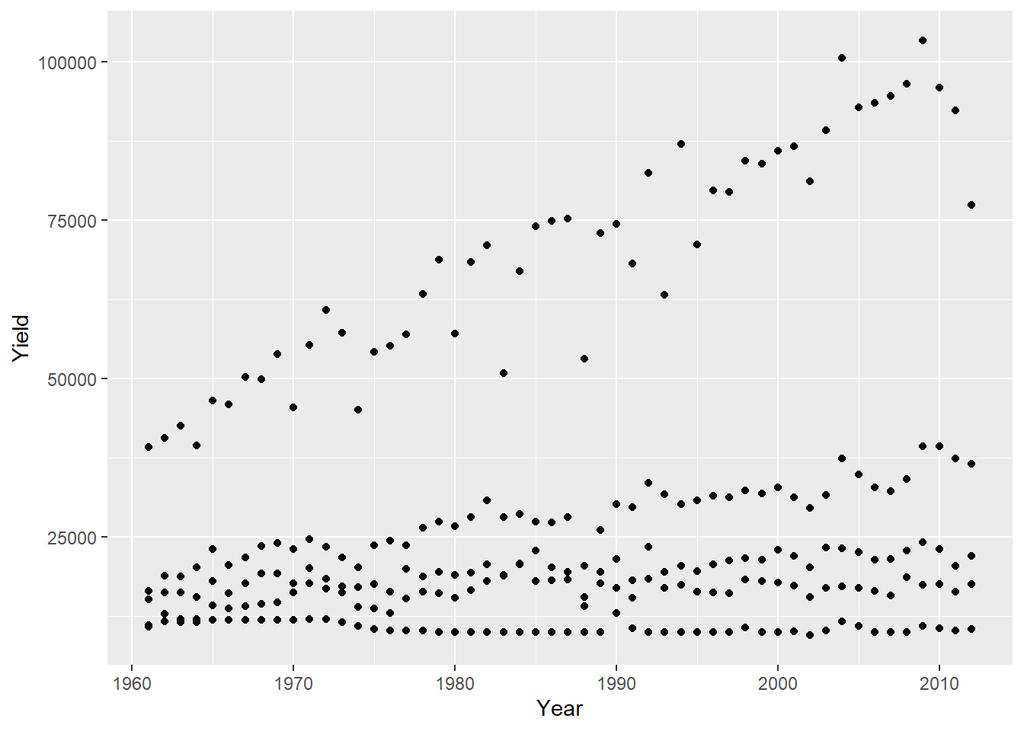

```r
ggplot(dat1l , aes(x = Year, y = Yield)) + geom_point()
```

where the function, `ggplot`, is passed the data frame name whose content will be mapped; the `aes` function is given data-to-geometry mapping instructions (`Year` is mapped to the x-axis and `Yield` is mapped to the y-axis); and `geom_point` is the geometry type.

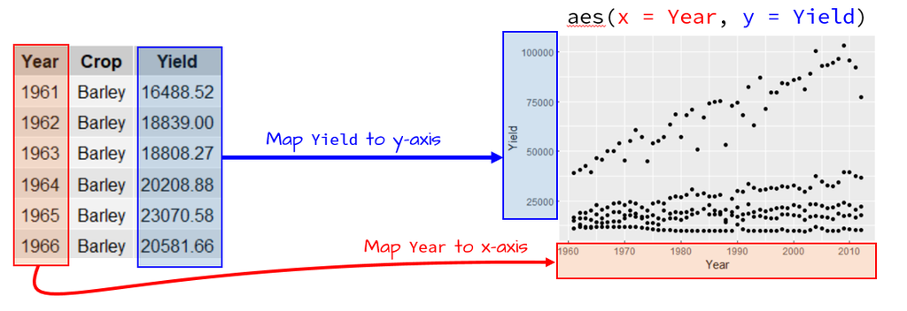

If we wanted to include a third variable, crop type, to the map, we would need to map its aesthetics: here we’ll map `Crop` to the color element of the geom.

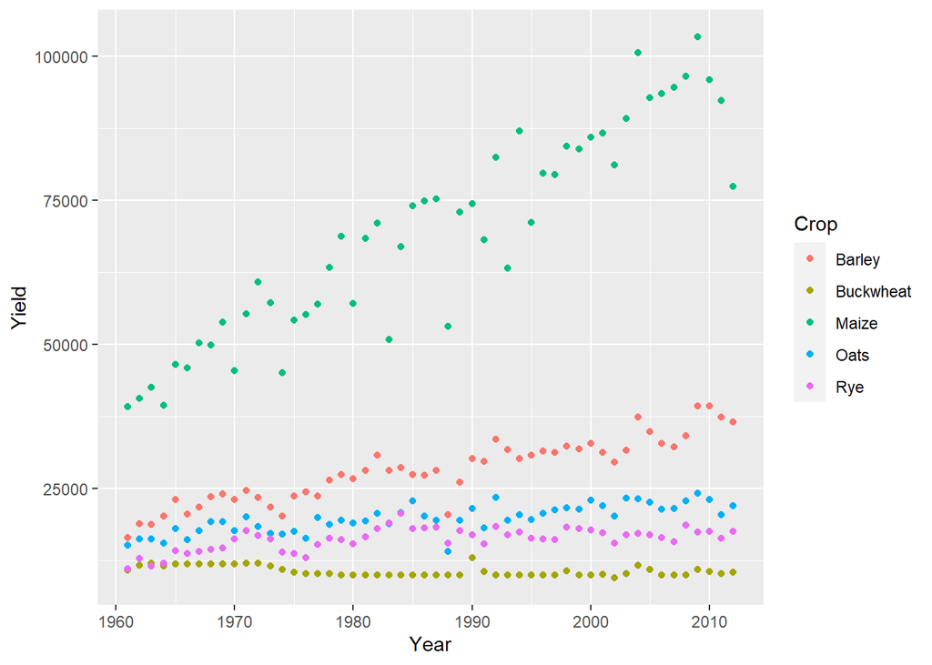

```r
ggplot(dat1l , aes(x = Year, y = Yield, color = Crop)) + geom_point()
```

The parameter color acts as a grouping parameter whereby the groups are assigned unique colors.

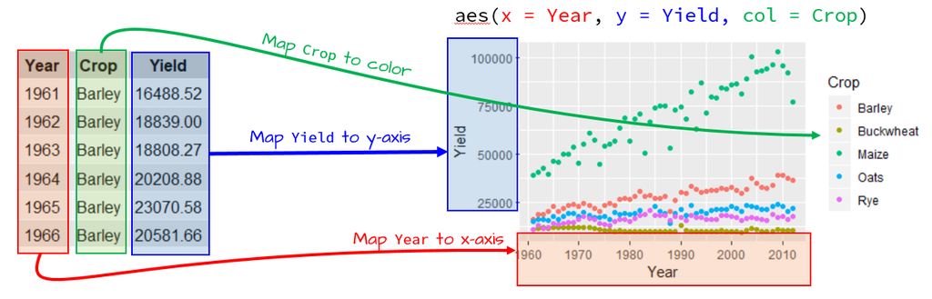

If we want to plot lines instead of points, simply substitute the geometry type with the `geom_line` geometry.

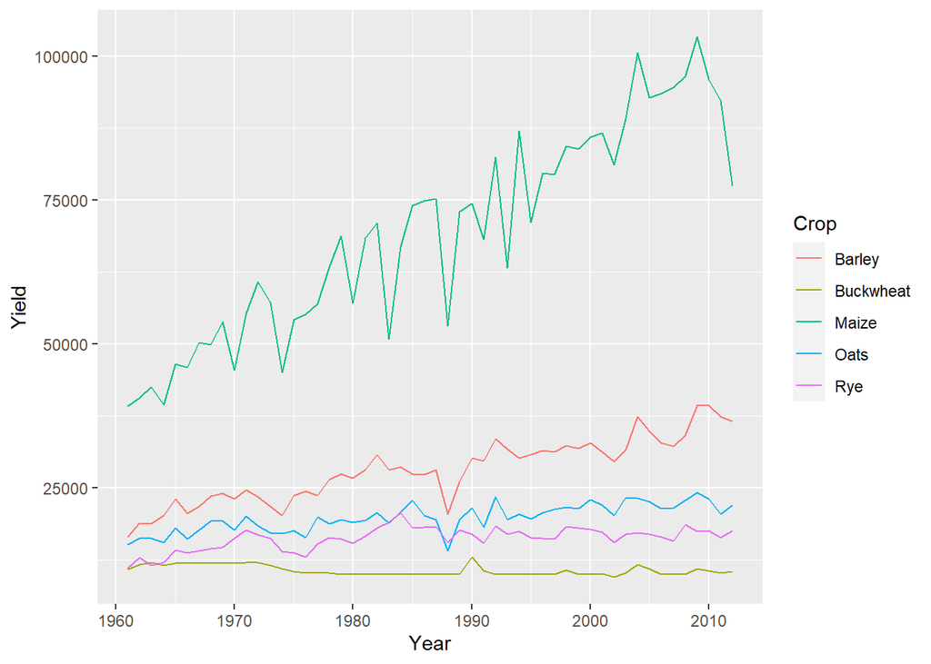

```r
ggplot(dat1l , aes(x = Year, y = Yield, color = Crop)) + geom_line()
```

Note that the aesthetics are still mapped in the same way with `Year` mapped to the x coordinate, `Yield` mapped to the y coordinate and `Crop` mapped to the geom’s color.

Note that the parameters `x=` and `y=` can be omitted from the syntax reducing the line of code to:

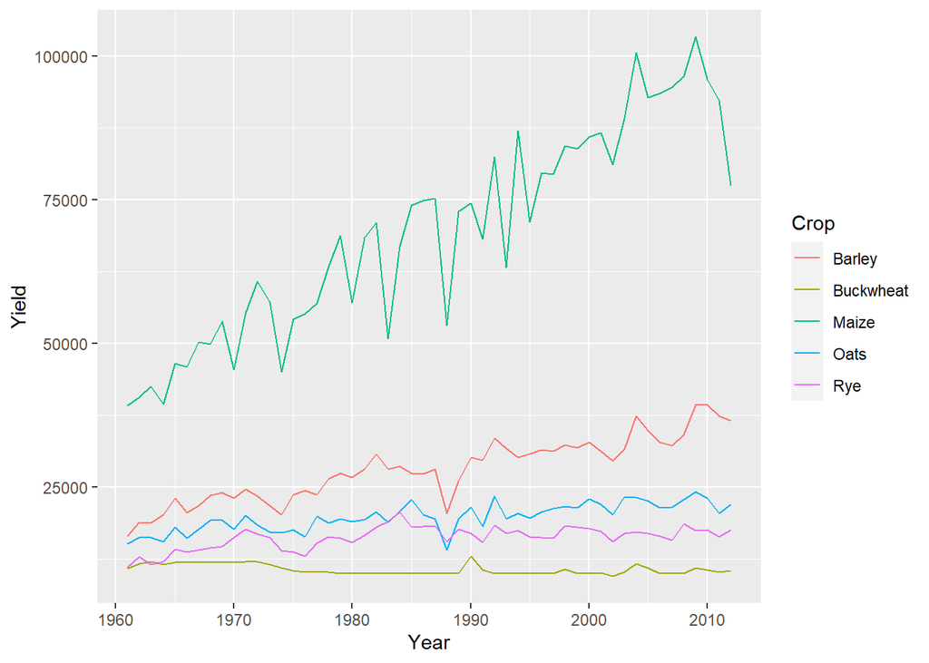

```r
ggplot(dat1l , aes(Year, Yield, color = Crop)) + geom_line()
```

### Geometries

Examples of a few available geometric elements follow.

#### `geom_line`

`geom_line` generates line geometries. We’ll use data from `dat1w` to generate a simple plot of oat yield as a function of year.

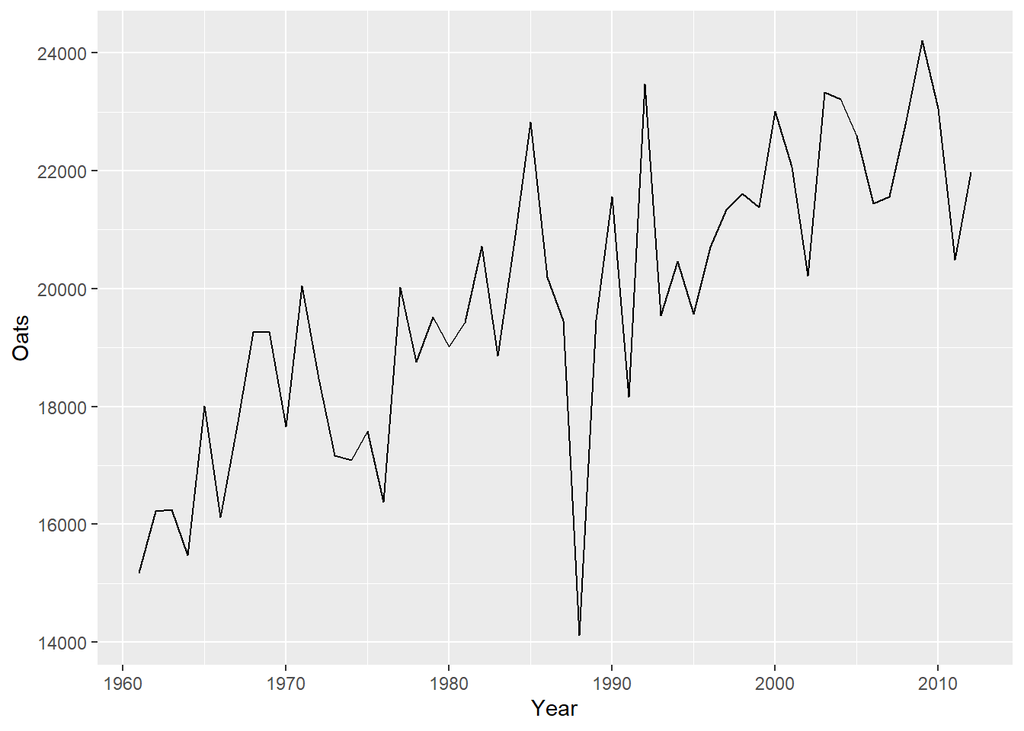

```r
ggplot(dat1w, aes(x = Year, y = Oats)) + geom_line()
```

Parameters such as color and linetype can be passed directly to the `geom_line` function:

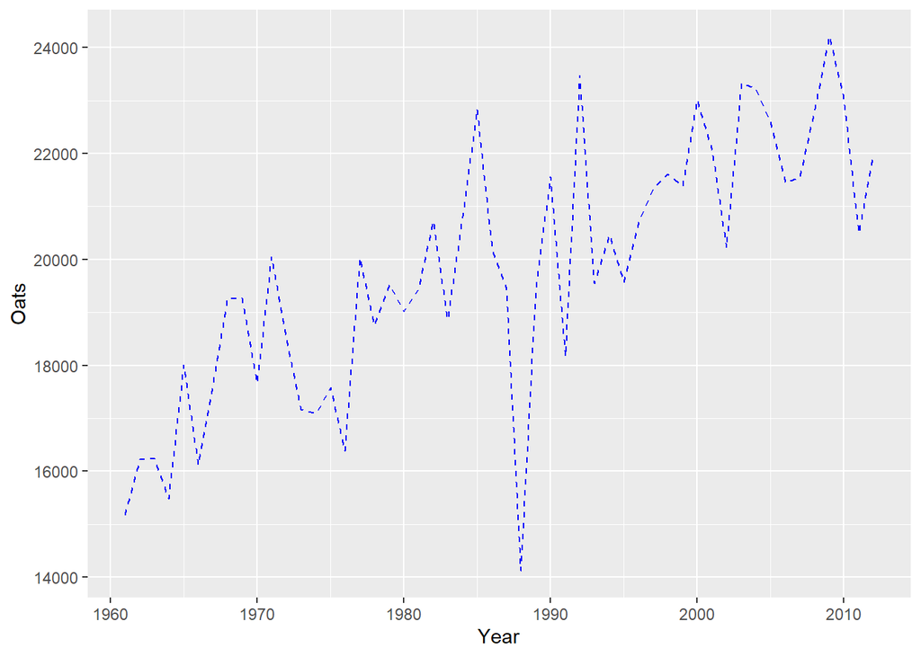

```r
ggplot(dat1w, aes(x = Year, y = Oats)) +
  geom_line(linetype = 2, colour = "blue", size=0.4)
```

Note the difference in how `colour=` is implemented here. It’s no longer **mapping** a variable’s levels to a range of colors as when it’s called inside of the `aes` function, instead, it’s **setting** the line color to blue.

#### `geom_point`

This generates point geometries. This is often used in generating scatterplots. For example, using `dat` dataste to plot male income (variable `B20004013`) vs female income (variable `B20004007`):

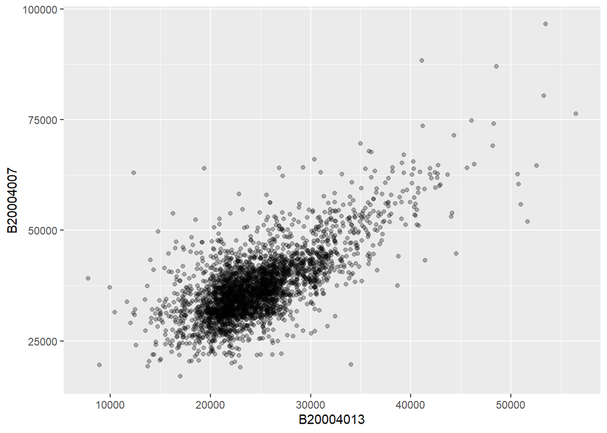

```r
ggplot(dat2, aes(x = B20004013, y = B20004007)) + geom_point(alpha = 0.3)
```

As did earlier, we modify the point’s transparency by passing the `alpha=0.3` parameter to the `geom_point` function. Other parameters that can be passed to point geoms include `colour`, `pch` and `cex`.

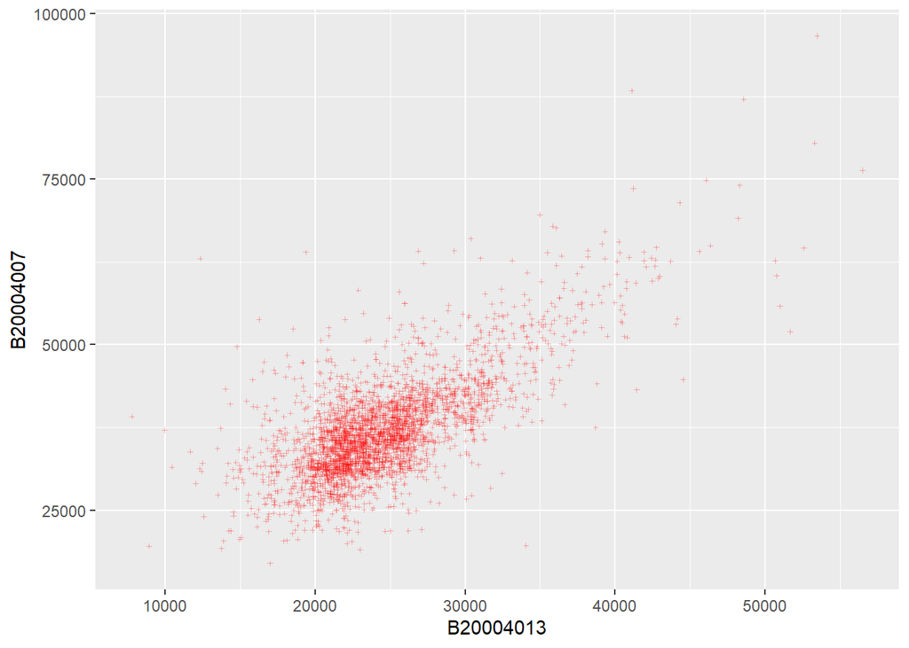

```r
ggplot(dat2, aes(x = B20004013, y = B20004007)) +
  geom_point(colour = "red", pch=3 , alpha = 0.3, cex=0.6)
```

#### `geom_hex`

When a bivariate scatter plot has too many overlapping points, it may be helpful to bin the observations into regular hexagons. This provides the number of observations per bin.

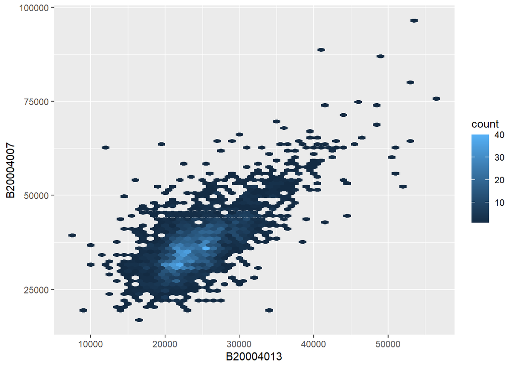

```r
library(hexbin)
ggplot(dat2, aes(x = B20004013, y = B20004007)) +
  geom_hex(binwidth = c(1000, 1000))
```

The `binwidth` argument defines the width and height of each bin in the variables’ axes units.

#### `geom_boxplot`

In the following example, a boxplot of `Yield` is generated for each `Crop` type.

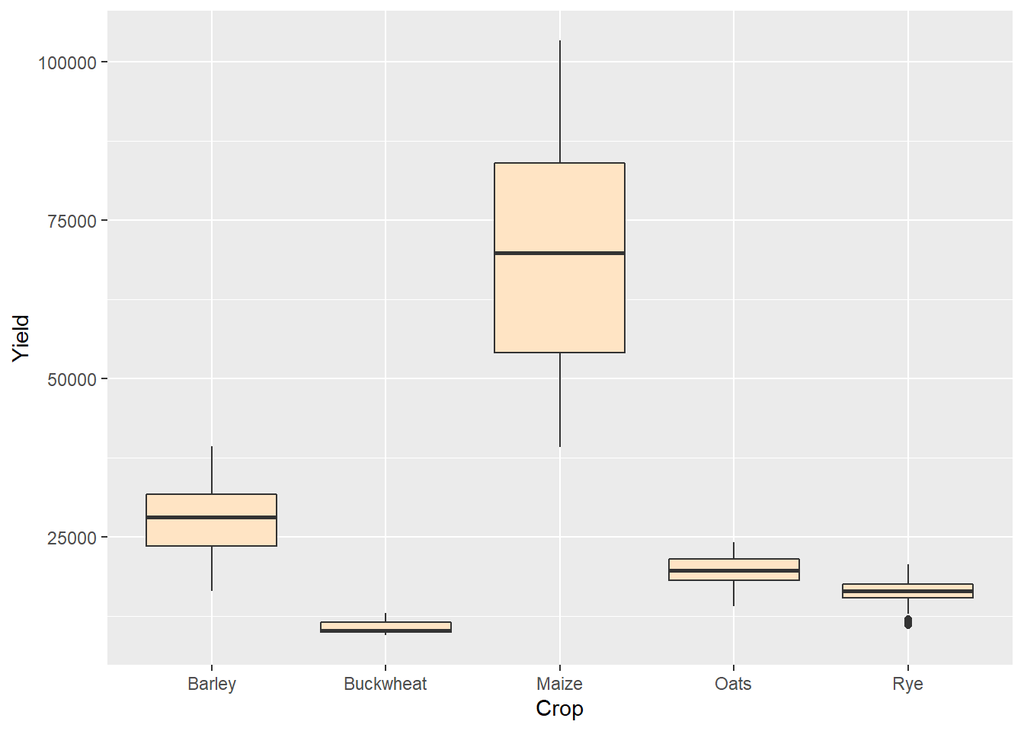

```r
ggplot(dat1l, aes(x = Crop, y = Yield)) + geom_boxplot(fill = "bisque")
```

If we want to generate a single boxplot (for example for all yields irrespective of crop type) we need to pass a dummy variable to `x=`:

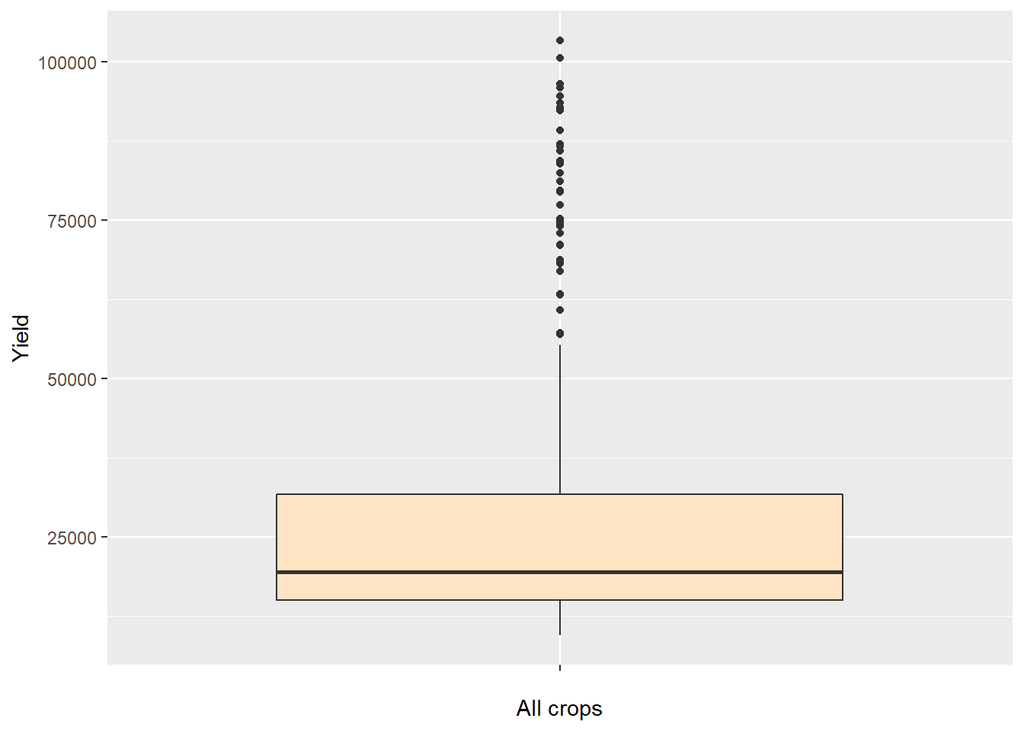

```r
ggplot(dat1l, aes(x = "", y = Yield)) +
  geom_boxplot(fill = "bisque") + xlab("All crops")
```

#### `geom_violin`

A violin plot is a symmetrical version of a density plot which provides greater detail of a sample’s distribution than a boxplot.

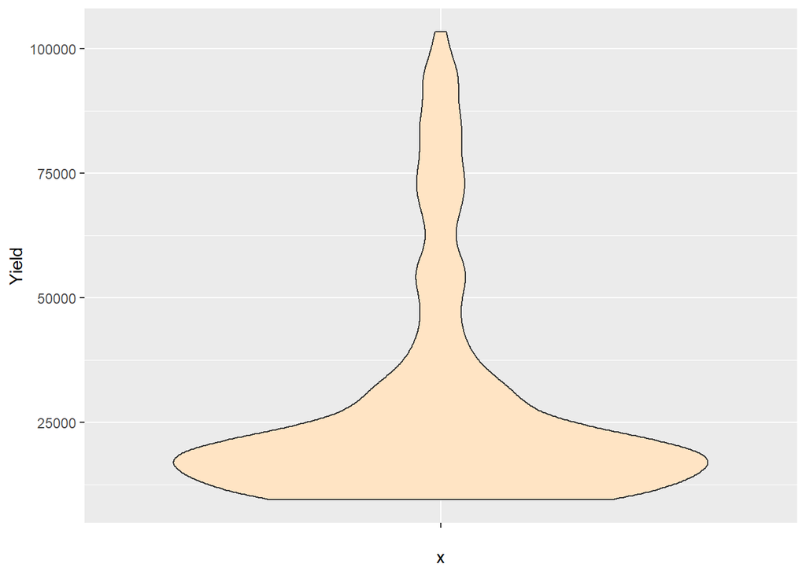

```r
ggplot(dat1l, aes(x = "", y = Yield)) + geom_violin(fill = "bisque")
```

#### `geom_histogram`

Histograms can be plotted for single variables only (unless faceting is used) as can be noted by the absence of a `y=` parameter in `aes`:

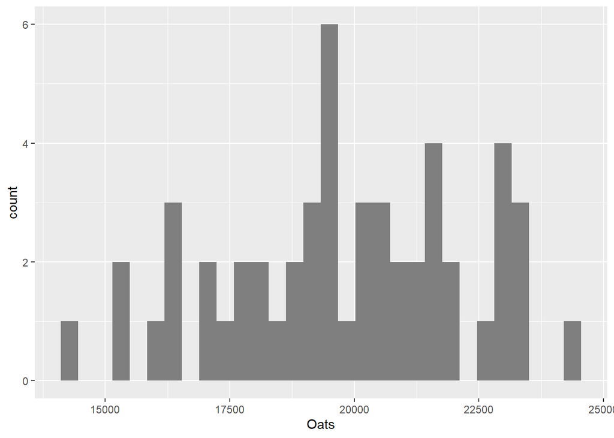

```r
ggplot(dat1w, aes(x = Oats)) + geom_histogram(fill = "grey50")
```

The bin widths can be specified in terms of the value’s units. In our example, the unit is yield of oats (in hg/Ha). So if we want to generate bin widths that cover 1000 hg/Ha (= 100 kg / Ha), we can type:

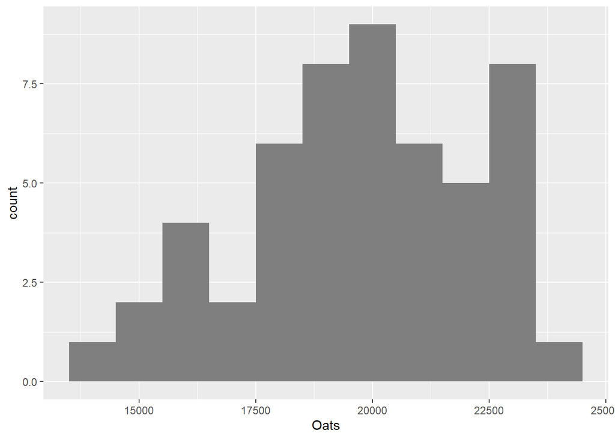

```r
ggplot(dat1w, aes(x = Oats)) +
  geom_histogram(fill = "grey50", binwidth = 1000)
```

If you want to control the number of bins, use the parameter `bins=` instead. For example, to set the number of bins to 8, modify the above code chunk as follows:

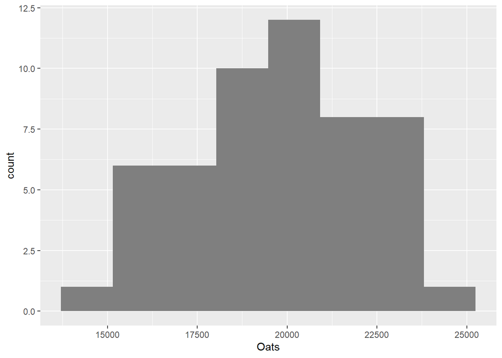

```r
ggplot(dat1w, aes(x = Oats)) +
  geom_histogram(fill = "grey50", bins = 8)
```

#### `geom_bar`

Bar plots are used to summaries the counts of a categorical value. For example, to plot the number of counties in each state (note that each record in `dat2` is assigned a county):

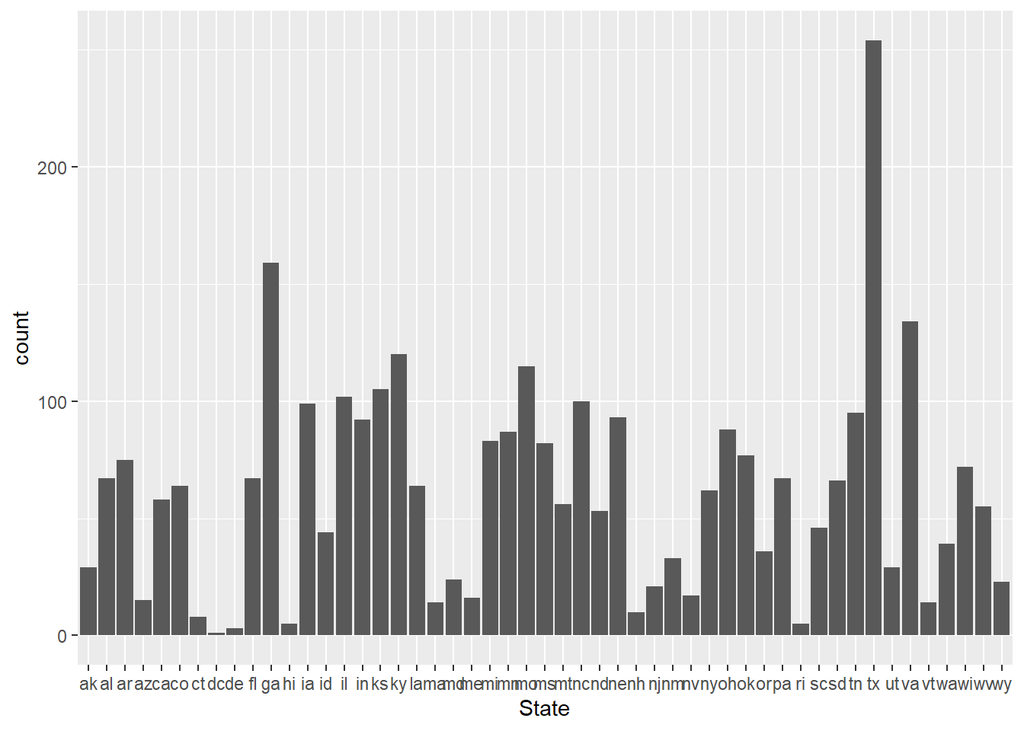

```r
ggplot(dat2, aes(State)) + geom_bar()
```

To sort the bars by length we need to rearrange the State factor level order based on the number of counties in each state (which is the number of times a state appears in the data frame). We’ll make use of `forcats`’s `fct_infreq` function to reorder the State factor levels based on frequency.

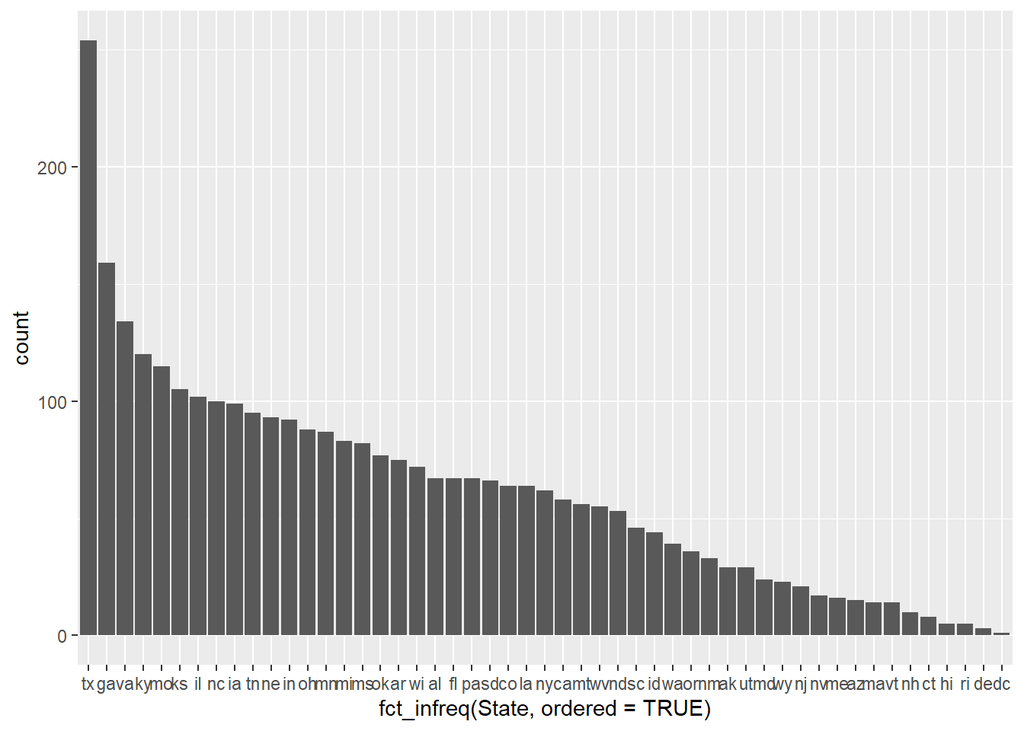

```r
library(forcats)
ggplot(dat2, aes(fct_infreq(State,ordered = TRUE))) + geom_bar()
```

If we want to reverse the order (i.e. plot from smallest number of counties to greatest), wrap the `fct_infreq` function with `fct_rev`.

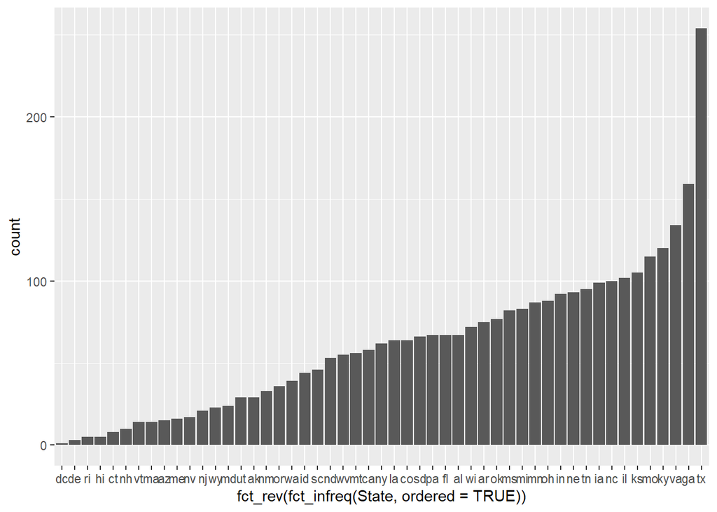

```r
ggplot(dat2, aes(fct_rev(fct_infreq(State,ordered = TRUE)))) + geom_bar()
```

The `geom_bar` function can also be used with count values (i.e. variable already summarized by count). First, we’ll summaries the number of counties by state using the dplyr package. This will generate a data frame with just 51 records: one for each of the 50 states and the District of Columbia.

```r
library(dplyr)
dat2.ct <- dat2 %>% group_by(State) %>%
                summarize(Counties = n())
head(dat2.ct)
```

```
## # A tibble: 6 x 2
##   State Counties
##   <chr>    <int>
## 1 ak          29
## 2 al          67
## 3 ar          75
## 4 az          15
## 5 ca          58
## 6 co          64
```

When using summarized data, we must pass the parameter `stat="identity"` to the geom_bar function. We must also explicitly map the *x* and *y* axes geometries. Note that since we are now generating bar heights from a value field and not a frequency, we will need to use another `forcats` ordering function called `fct_reorder`. This function takes three parameters: the variable to be ordered (`State`), the variable whose values will determine the order (`Counties`) and the function, `fun=`, which defines the statistic used to summaries the sorting variable. Since there is just one value per state, we can use any summary statistic such as `median`, `mean`, `sum`, `min` or `max`.

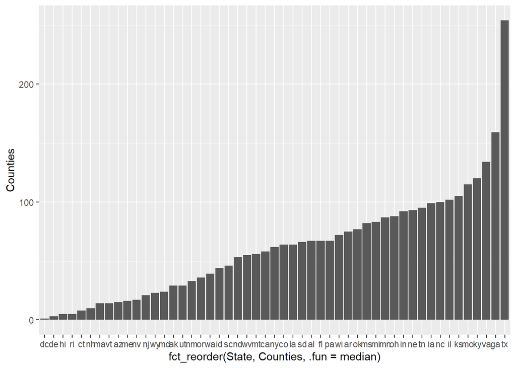

```r
ggplot(dat2.ct, aes(x=fct_reorder(State, Counties, .fun = median), y = Counties)) + geom_bar(stat = "identity")
```

Note that you can replace `fct_reorder` with the base function `reorder` we saw before.

#### dot plot

The dot plot is an alternative way to visualize counts as a function of a categorical variable. Instead of mapping `State` to the x-axis, we’ll map it to the y-axis.

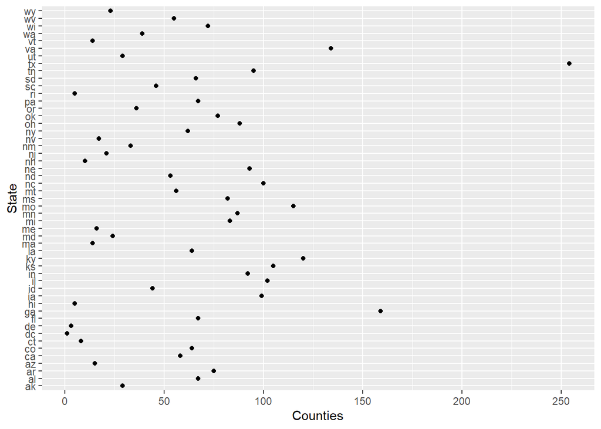

```r
ggplot(dat2.ct , aes(x = Counties, y = State)) + geom_point()
```

Dot plot graphics benefit from sorting–more so then bar plots. Here, we’ll make use of **`forcats::fct_reorder`** function.

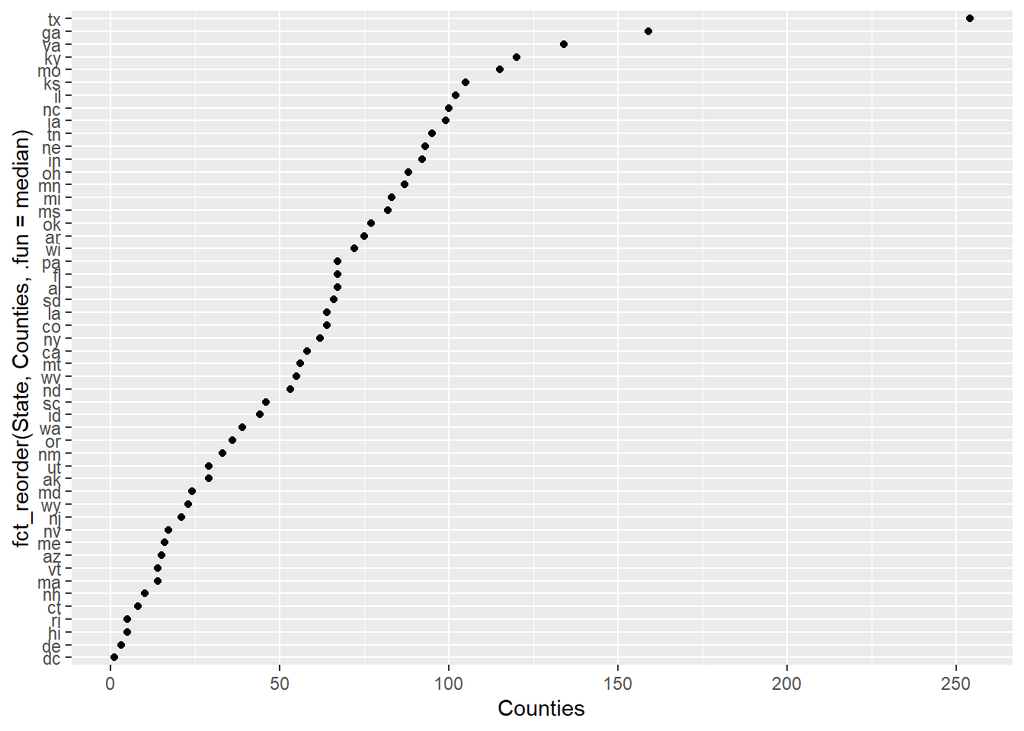

```r
ggplot(dat2.ct , aes(x = Counties, y = fct_reorder(State, Counties, .fun = median))) + geom_point()
```

#### Combining geometries

Obviously, geometries can be layered. For example, to overlay a linear regression line to the data we can add the geom_smooth layer:

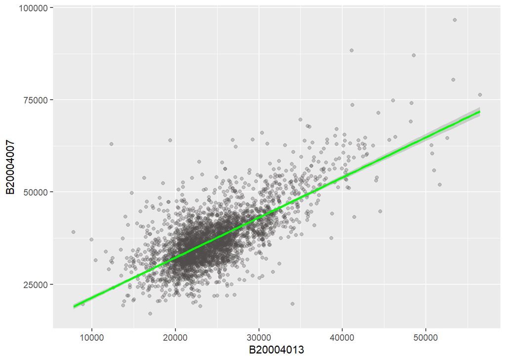

```r
ggplot(dat2, aes(x = B20004013, y = B20004007)) +
  geom_point(alpha = 0.3, color='#4f4b4b') +
  geom_smooth(method = "lm", color='green')
```

The `geom_smooth` can be used to fit other *lines* such as a loess:

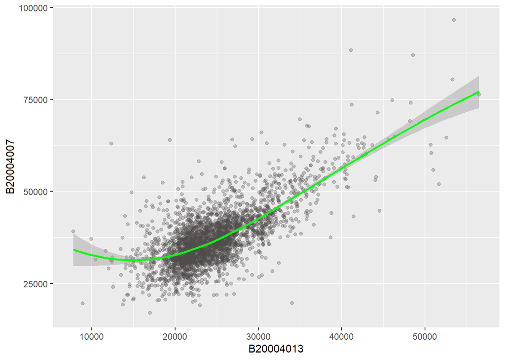

```r
ggplot(dat2, aes(x = B20004013, y = B20004007)) +
  geom_point(alpha = 0.3, color='#4f4b4b') +
  geom_smooth(method = "loess", color='green')
```

The confidence interval can be removed from the smooth geometry by specifying `se = FALSE`.

### Tweaking a ggplot2 graph

Little trick for data visualization with ggplot2 avalibale [here](https://rstudio.com/wp-content/uploads/2015/03/ggplot2-cheatsheet.pdf)